# Red Wine EDA by Terry Li

## 3.3 Quality vs Volatile Acidity

```r
with(wine, by(volatile.acidity, factor(quality), summary))
```

```
## factor(quality): 3
##    Min. 1st Qu.  Median    Mean 3rd Qu.    Max.
##  0.4400  0.6475  0.8450  0.8845  1.0100  1.5800
## --------------------------------------------------------
## factor(quality): 4
##    Min. 1st Qu.  Median    Mean 3rd Qu.    Max.
##   0.230   0.530   0.670   0.694   0.870   1.130
## --------------------------------------------------------
## factor(quality): 5
##    Min. 1st Qu.  Median    Mean 3rd Qu.    Max.
##   0.180   0.460   0.580   0.577   0.670   1.330
## --------------------------------------------------------
## factor(quality): 6
##    Min. 1st Qu.  Median    Mean 3rd Qu.    Max.
##  0.1600  0.3800  0.4900  0.4975  0.6000  1.0400
## --------------------------------------------------------
## factor(quality): 7
##    Min. 1st Qu.  Median    Mean 3rd Qu.    Max.
##  0.1200  0.3000  0.3700  0.4039  0.4850  0.9150
## --------------------------------------------------------
## factor(quality): 8
##    Min. 1st Qu.  Median    Mean 3rd Qu.    Max.
##  0.2600  0.3350  0.3700  0.4233  0.4725  0.8500
```

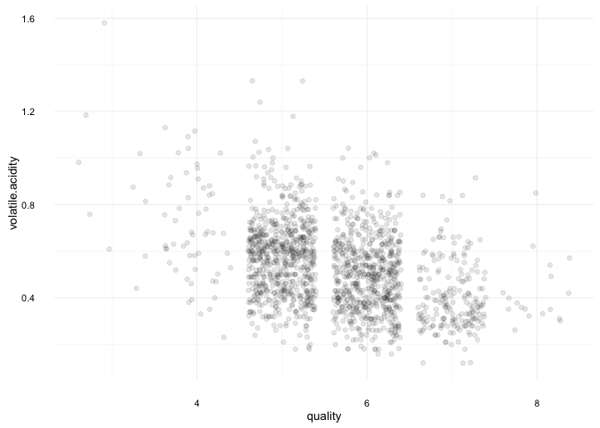

```r
ggplot(aes(x = quality, y = volatile.acidity), data = wine) +
  geom_jitter(alpha = 1/10)
```

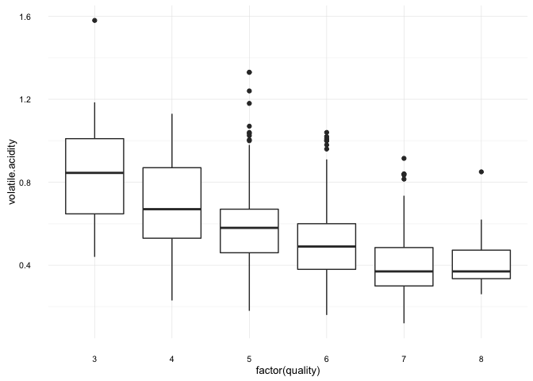

```r
ggplot(aes(x = factor(quality), y = volatile.acidity), data = wine) +
  geom_boxplot()
```

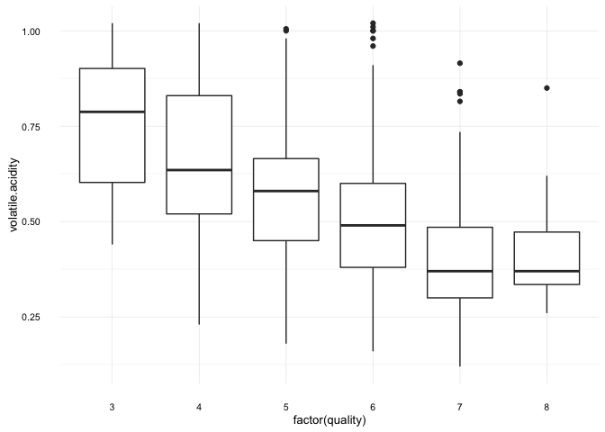

```r
ggplot(aes(x = factor(quality), y = volatile.acidity), data = wine) +
  geom_boxplot() +
  ylim(min(wine$volatile.acidity), quantile(wine$volatile.acidity, 0.99))
```

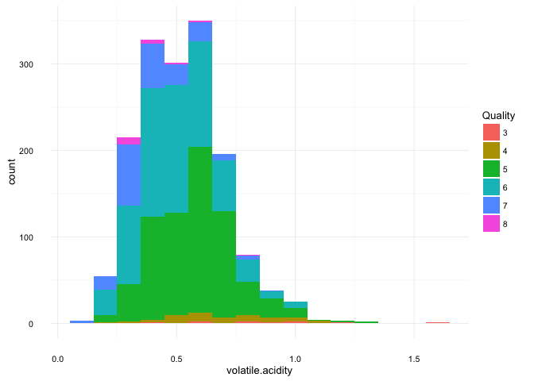

```r
ggplot(aes(x = volatile.acidity), data = wine) +
  geom_histogram(aes(fill = factor(quality)), binwidth = 0.1) +
  scale_color_brewer(type = 'div', name = 'Quality') +
  scale_fill_discrete(name = 'Quality')
```

## 3.4 Quality vs Sulphates

```r
with(wine, by(sulphates, factor(quality), summary))
```

```
## factor(quality): 3
##    Min. 1st Qu.  Median    Mean 3rd Qu.    Max.
##  0.4000  0.5125  0.5450  0.5700  0.6150  0.8600
## --------------------------------------------------------
## factor(quality): 4
##    Min. 1st Qu.  Median    Mean 3rd Qu.    Max.
##  0.3300  0.4900  0.5600  0.5964  0.6000  2.0000
## --------------------------------------------------------
## factor(quality): 5
##    Min. 1st Qu.  Median    Mean 3rd Qu.    Max.
##   0.370   0.530   0.580   0.621   0.660   1.980
## --------------------------------------------------------
## factor(quality): 6
##    Min. 1st Qu.  Median    Mean 3rd Qu.    Max.
##  0.4000  0.5800  0.6400  0.6753  0.7500  1.9500
## --------------------------------------------------------
## factor(quality): 7
##    Min. 1st Qu.  Median    Mean 3rd Qu.    Max.
##  0.3900  0.6500  0.7400  0.7413  0.8300  1.3600
## --------------------------------------------------------
## factor(quality): 8
##    Min. 1st Qu.  Median    Mean 3rd Qu.    Max.
##  0.6300  0.6900  0.7400  0.7678  0.8200  1.1000
```

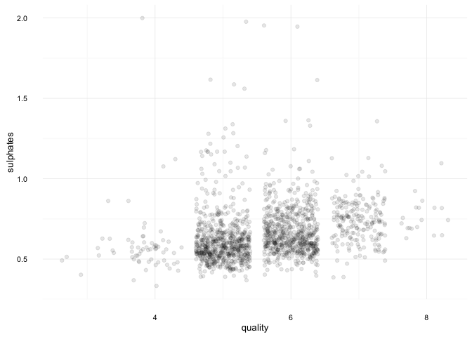

```r
ggplot(aes(x = quality, y = sulphates), data = wine) +
  geom_jitter(alpha = 1/10)
```

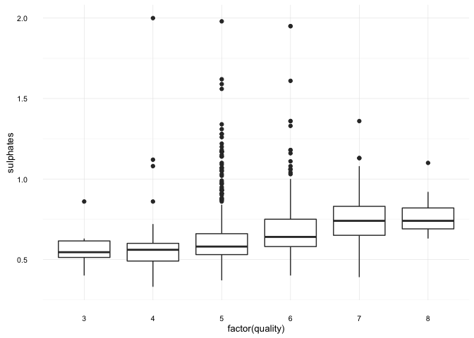

```r
ggplot(aes(x = factor(quality), y = sulphates), data = wine) +
  geom_boxplot()
```

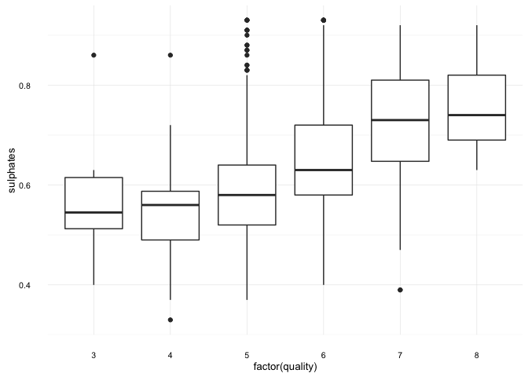

```r
ggplot(aes(x = factor(quality), y = sulphates), data = wine) +
  geom_boxplot() +
  ylim(min(wine$sulphates), quantile(wine$sulphates, 0.95))
```

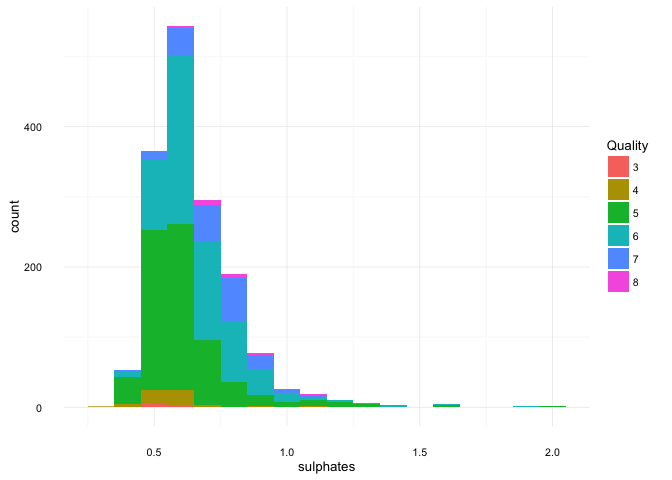

```r
ggplot(aes(x = sulphates), data = wine) +
  geom_histogram(aes(fill = factor(quality)), binwidth = 0.1) +
  scale_color_brewer(type = 'div', name = 'Quality') +
  scale_fill_discrete(name = 'Quality')
```

## 3.5 Quality vs Citric Acid

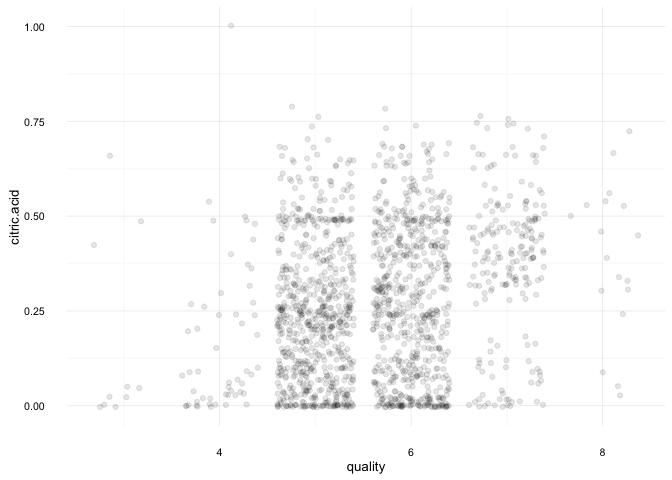

```r
ggplot(aes(x = quality, y = citric.acid), data = wine) +
  geom_jitter(alpha = 1/10, position = 'jitter')
```

```r
with(wine, by(citric.acid, factor(quality), summary))
```

```
## factor(quality): 3
##    Min. 1st Qu.  Median    Mean 3rd Qu.    Max.
##  0.0000  0.0050  0.0350  0.1710  0.3275  0.6600
## --------------------------------------------------------
## factor(quality): 4
##    Min. 1st Qu.  Median    Mean 3rd Qu.    Max.
##  0.0000  0.0300  0.0900  0.1742  0.2700  1.0000
## --------------------------------------------------------
## factor(quality): 5
##    Min. 1st Qu.  Median    Mean 3rd Qu.    Max.
##  0.0000  0.0900  0.2300  0.2437  0.3600  0.7900
## --------------------------------------------------------
## factor(quality): 6
##    Min. 1st Qu.  Median    Mean 3rd Qu.    Max.
##  0.0000  0.0900  0.2600  0.2738  0.4300  0.7800
## --------------------------------------------------------
## factor(quality): 7
##    Min. 1st Qu.  Median    Mean 3rd Qu.    Max.
##  0.0000  0.3050  0.4000  0.3752  0.4900  0.7600
## --------------------------------------------------------
## factor(quality): 8
##    Min. 1st Qu.  Median    Mean 3rd Qu.    Max.
##  0.0300  0.3025  0.4200  0.3911  0.5300  0.7200
```

```r
with(wine, by(citric.acid, factor(quality), IQR))
```

```
## factor(quality): 3
## [1] 0.3225
## --------------------------------------------------------
## factor(quality): 4
## [1] 0.24
## --------------------------------------------------------
## factor(quality): 5
## [1] 0.27
## --------------------------------------------------------
## factor(quality): 6
## [1] 0.34
## --------------------------------------------------------
## factor(quality): 7
## [1] 0.185
## --------------------------------------------------------
## factor(quality): 8
## [1] 0.2275
```

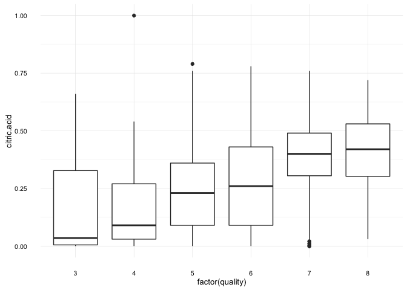

```r
ggplot(aes(x = factor(quality), y = citric.acid), data = wine) +
  geom_boxplot()
```

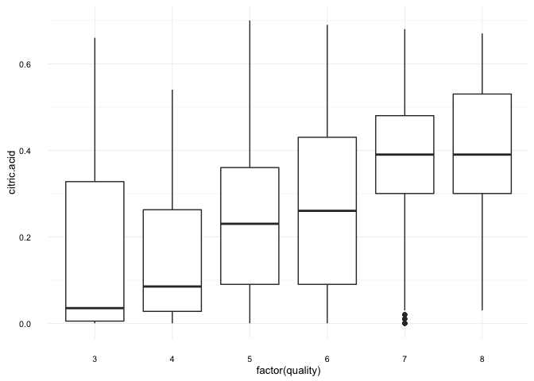

```r
ggplot(aes(x = factor(quality), y = citric.acid), data = wine) +
  geom_boxplot() +
  ylim(min(wine$citric.acid), quantile(wine$citric.acid, 0.99))
```

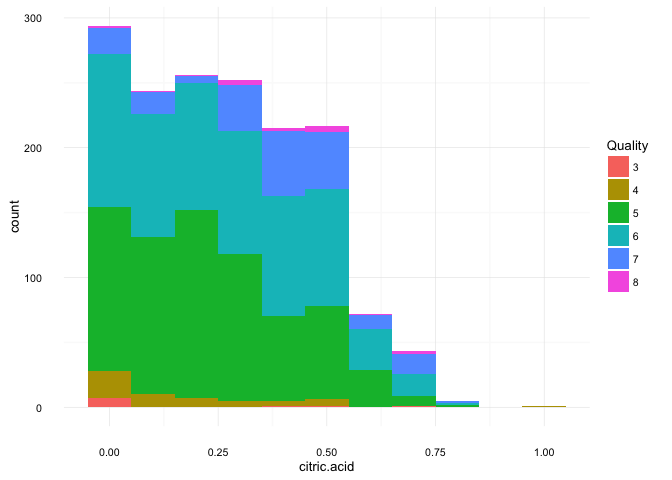

```r
ggplot(aes(x = citric.acid), data = wine) +
  geom_histogram(aes(fill = factor(quality)), binwidth = 0.1) +
  scale_color_brewer(type = 'div', name = 'Quality') +
  scale_fill_discrete(name = 'Quality')
```

# 4 Bivariate Analysis

### 4.0.1 Talk about some of the relationships you observed in this part of the investigation. How did the feature(s) of interest vary with other features in the dataset?

`quality` and `alochol` have the highest and position correlation.

`quality` and `volatile acidity` have an negative correlation.

Similar to `alcohol`, `sulphates`has a positive relationship with `quality`.

Lastly, `citric acid` also has a positive relationship with `quality`.

# 5 Multivariate Plots Section

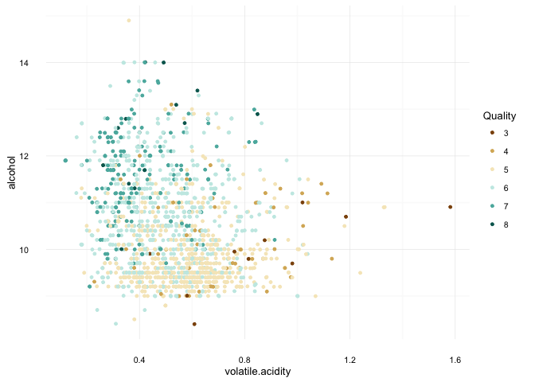

```r
ggplot(aes(x = volatile.acidity, y = alcohol, color = factor(quality)), data = wine) +
  geom_jitter(size = 1) +
  scale_color_brewer(type = 'div', guide = guide_legend(title = 'Quality'))
```

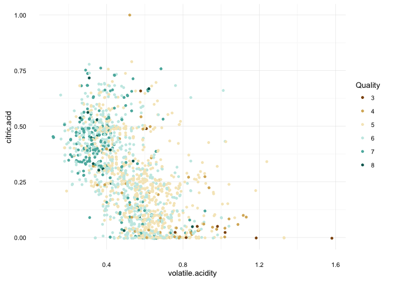

```r
ggplot(aes(x = volatile.acidity, y = citric.acid, color = factor(quality)), data = wine) +
  geom_jitter(size = 1) +
  scale_color_brewer(type = 'div', guide = guide_legend(title = 'Quality'))
```

# 6 Multivariate Analysis

### 6.0.1 Talk about some of the relationships you observed in this part of the investigation. Were there features that strengthened each other in terms of looking at your feature(s) of interest?

Per the first plot above, it is noted that the high quality wines have high alcohol percentrages and low valatile acidity.

### 6.0.2 Were there any interesting or surprising interactions between features?

It is interesting that. for citric acid, the value 0.00, 0.24 and 0.49 appeared much more frequently than the other obsered values.

# 7 Final Plots and Summary

### 7.0.1 Plot One

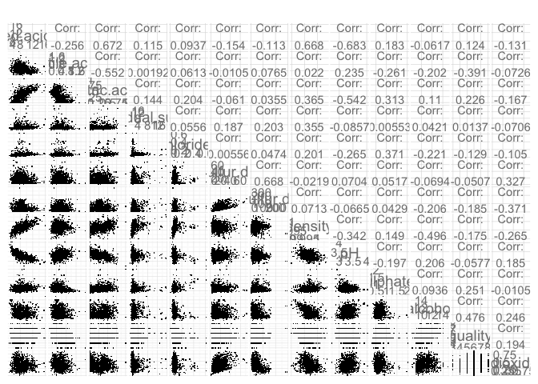

```r
wine.subset <- wine[, c(2:14)]

ggpairs(wine.subset, axisLabels = 'internal',
  lower = list(continuous = wrap("points", shape = I('.'))),
  upper = list(combo = wrap("box", outlier.shape = I('.'))))
```

### 7.0.2 Description One

The top correlations involving quality are as follows: - alcohol (0.476) - volatile acidity (-0.391) - sulphates (0.251) - citric acid (0.226)

### 7.0.3 Plot Two

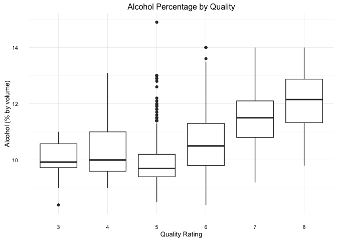

```r
ggplot(aes(x = factor(quality), y = alcohol), data = wine) +
  geom_boxplot() +
  ggtitle("Alcohol Percentage by Quality") +
  ylab("Alcohol (% by volume)") +
  xlab("Quality Rating")
```

### 7.0.4 Description Two

Alcohol has the strongest and position correlation (0.476) with quality among all the variables. There is clearly a positive relationship except at rating 5.

### 7.0.5 Plot Three

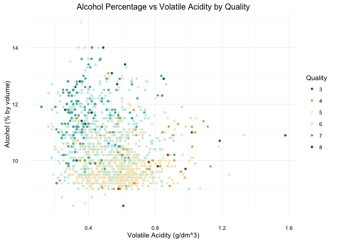

```r
ggplot(aes(x = volatile.acidity, y = alcohol, color = factor(quality)), data = wine) +
  geom_jitter(size = 1) +
  scale_color_brewer(type = 'div', guide = guide_legend(title = 'Quality')) +
  ggtitle("Alcohol Percentage vs Volatile Acidity by Quality") +
  ylab("Alcohol (% by volume)") +
  xlab("Volatile Acidity (g/dm^3)")
```

### 7.0.6 Description Three

Alochol percentage and volatile acidity are the 2 varaibles which have the strongest relationship with quality. It is noted that the high quality wines have high alcohol percentrages and low valatile acidity.

# 8 Reflection

The red wine data set contains information on almost 1,600 red wines across 13 variables. I started by understanding the individual variables in the data set, and then I explored interesting questions and leads as I continued to make observations on plots. Eventually, I explored the quality of red wines across many variables.

The new variable I created (sulfur dioxide ratio) did not add much value.

It would be even more interesting if the price of the wines are included in this dateset.